# Filter individuals

Lorenzo Bertola

Document last run on 2024-07-01

## 0. Background

Now that we have called and exported genotypes at the lineage level, let's filter invididuals based on missingness before we proceed with detecting sex-linked loci.

## 0. Load packages

```r
library(tidyverse)
library(janitor)
```

## 1. Read input data

Let’s import the lineage specific files

```r
my.dfs <- list.files(path="../4_filtering/",
                     pattern = ".all", full.names = TRUE)

my.dfs <- lapply(my.dfs, function(x){
  y <- read_delim(x, delim = "\t")
})
```

```
## ──────────────────────────────────────────────────────── Delimiter: "\t" chr
## (1): sampleID dbl (32126): scaffold_1_123180, scaffold_1_123170,
## scaffold_1_323714, scaffo...
## ──────────────────────────────────────────────────────── Delimiter: "\t" chr
## (1): sampleID dbl (22362): scaffold_1_671227, scaffold_1_671204,
## scaffold_1_778439, scaffo...
## ──────────────────────────────────────────────────────── Delimiter: "\t" chr
## (1): sampleID dbl (24351): scaffold_1_671227, scaffold_1_671204,
## scaffold_1_1547699, scaff...
```

Remove ".sort" from the end of the sample names as it is now redundant

```r
my.dfs <- lapply(my.dfs, function(x){
  y <- x %>% mutate(sampleID = gsub(".sort","",sampleID))

  return(y)
})
```

## 2. Filter individuals by call rate

Let's calculate call rate for each individual.

```r
CallRate <- lapply(my.dfs, function(x){
  #sum the number of "-1" for each row, divide by the total
  y <- 1 - rowSums(x[,2:ncol(x)]=="-1")/(ncol(x)-1)

  #make a dataframe with sample name and call rate
  y <- tibble("sampleID"=x$sampleID,
              "callRate"=as.numeric(y))

  return(y)
})
```

Add species, population and sex information, which are found in the sample name

```r
CallRate <- lapply(CallRate, function(x){
  y <- x %>% mutate(Species = substr(sampleID,1,4),
                    Pop = substr(sampleID,6,7))

  return(y)
})
```

Plot call rate by individual at the species level as a histogram.

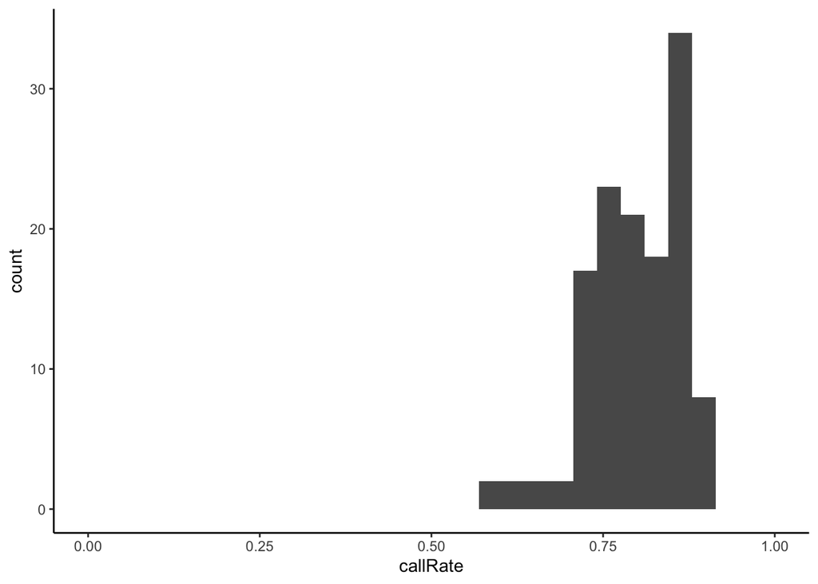

```r
plot2 <- lapply(CallRate, function(x){
  y <- ggplot(x) +
    geom_histogram(aes(x=callRate)) + xlim(0,1) +
    theme_classic()

  return(y)
})

plot2[[1]]
```

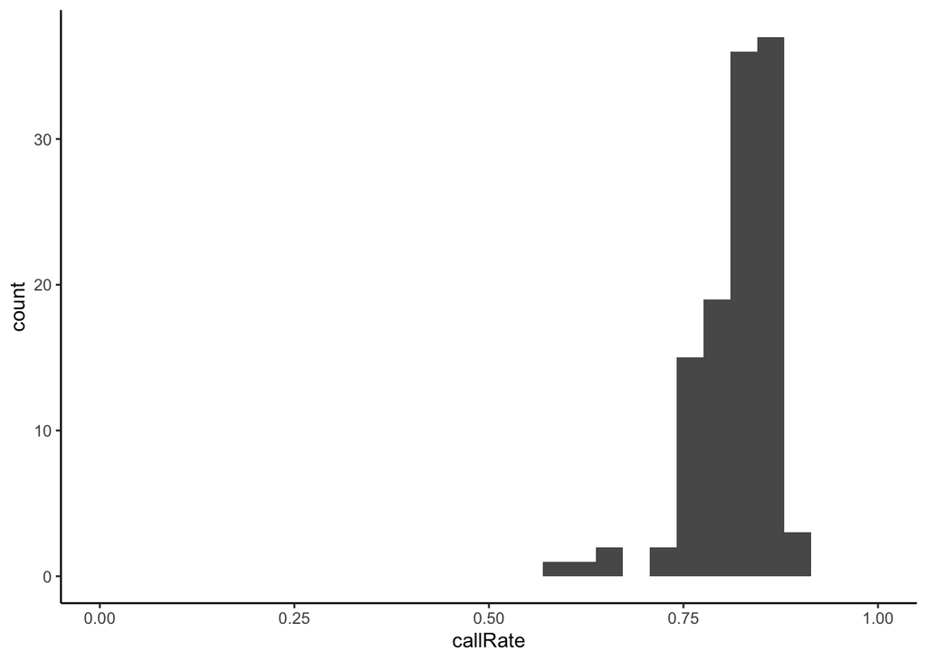

```r
plot2[[2]]
```

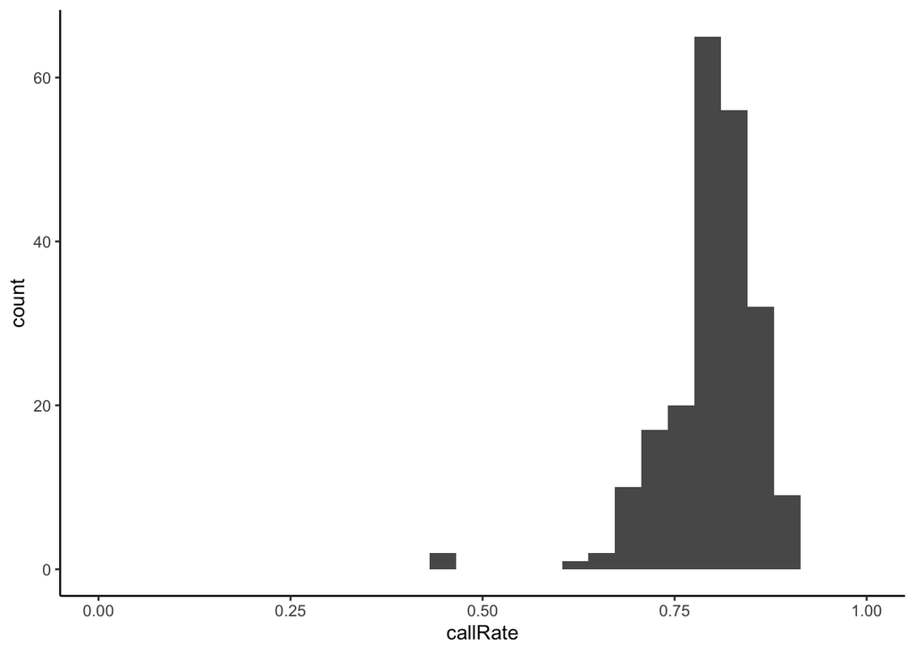

```r
plot2[[3]]
```

Then also plot at the sampling site level as boxplots.

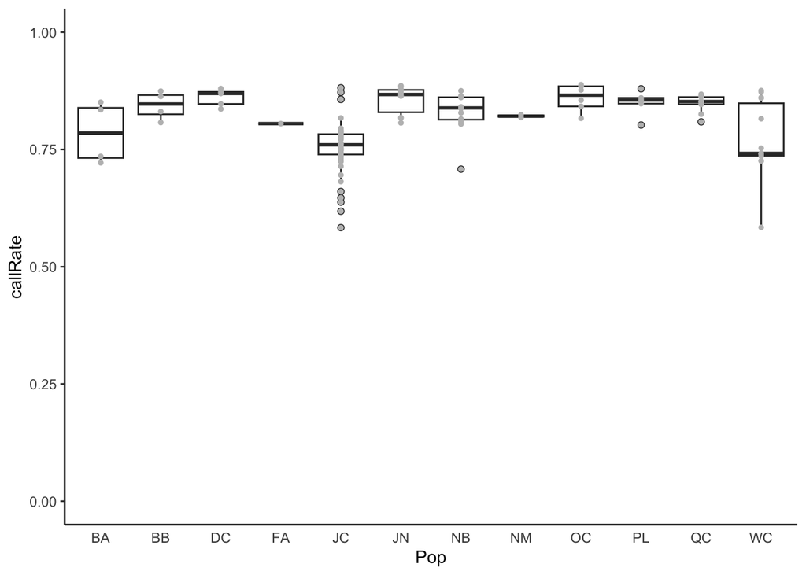

```r
plot1 <- lapply(CallRate, function(x){
  y <- ggplot(x) +
  geom_boxplot(aes(y=callRate,x=Pop)) +
  geom_point(aes(y=callRate,x=Pop),size=1, colour="grey") +
  ylim(0,1) + theme_classic() +
  theme(axis.ticks.x = element_blank())

  return(y)
})

plot1[[1]]
```

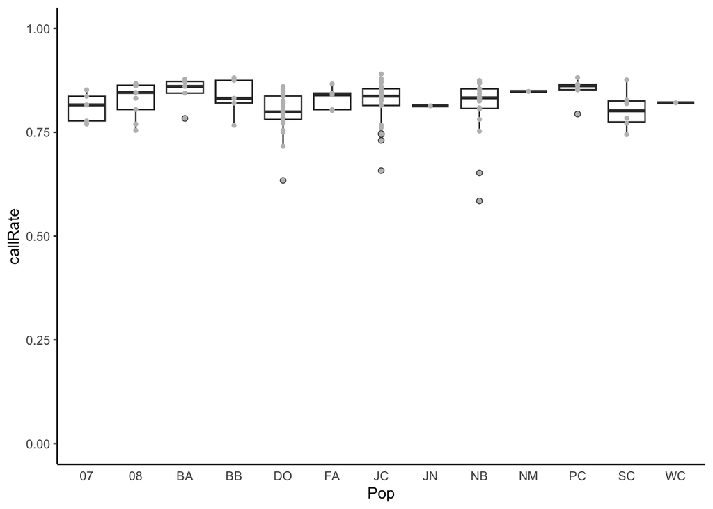

```r
plot1[[2]]
```

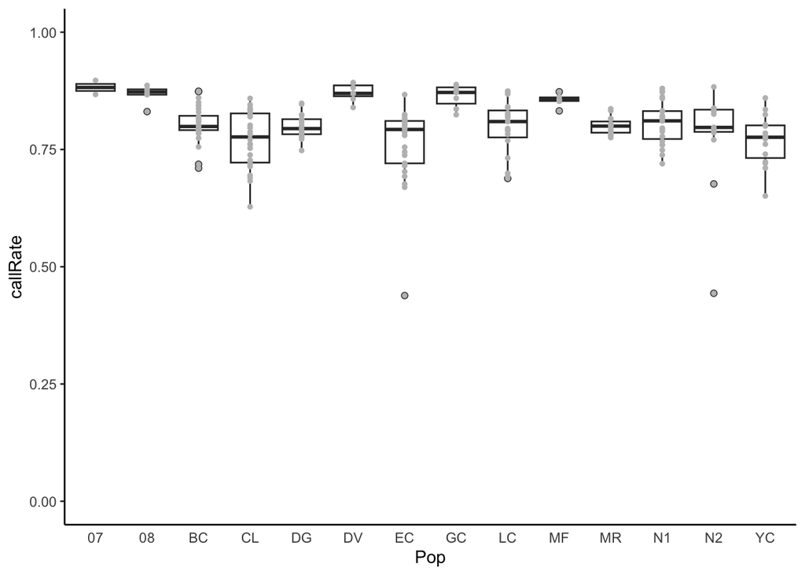

```r
plot1[[3]]
```

These three plots represent the LM, LN, and LS lineages respectively. Let's name the list elements for clarity later on.

```r
names(CallRate) <- c("LM","LN","LS")
```

And now let's identify which individuals have a call rate < 0.65.

```r
lapply(CallRate, function(x){
  x %>% filter(callRate < 0.65)
})
```

```
## $LM
## # A tibble: 5 × 4
##   sampleID                 callRate Species Pop
##   <chr>                       <dbl> <chr>   <chr>
## 1 LM_M_JC_CONX1029_M_a        0.638 LM_M    JC
## 2 LM_M_JC_CONX1029_M_b        0.647 LM_M    JC
## 3 LM_M_JC_CONX3059_F          0.583 LM_M    JC
## 4 LM_M_JC_lowerKindie1_M_b    0.618 LM_M    JC
## 5 LM_M_WC_CONX6278_M          0.584 LM_M    WC
##
## $LN
## # A tibble: 2 × 4
##   sampleID             callRate Species Pop
##   <chr>                   <dbl> <chr>   <chr>
## 1 LS_N_DO_CONX6382_M      0.634 LS_N    DO
## 2 LM_M_NB_CONX6220_M_b    0.585 LM_M    NB
##
## $LS
## # A tibble: 3 × 4
##   sampleID         callRate Species Pop
##   <chr>               <dbl> <chr>   <chr>
## 1 LS_S_CL_458_M       0.628 LS_S    CL
## 2 LS_S_EC_401_M       0.439 LS_S    EC
## 3 LS_S_N2_540B_M_b    0.443 LS_S    N2
```

Name list elements in the original list based on lineage as well.

```r
names(my.dfs) <- c("LM","LN","LS")
```

Make vector of individuals to retain (i.e., those with a call rate > 0.65)

```r
to.retain <- lapply(CallRate, function(x){
  y <- x %>% filter(callRate > 0.65) %>% pull(sampleID)

  return(y)
})
```

Filter to retain only wanted individuals

```r
my.dfs <- mapply(function(a,b){
  y <- a %>% filter(sampleID %in% b)

  return(y)
}, my.dfs, to.retain)
```

Next, let's add species and pop data to our original dataframes for filtering later.

```r
my.dfs <- lapply(my.dfs, function(x){
  y <- x %>% mutate(Species = substr(sampleID,1,4),
                    Pop = substr(sampleID,6,7)) %>%
    select(sampleID,Species,Pop,everything())

  return(y)
})
```

We will remove samples from LN and LS which come from two and four small populations with not enough samples for any of the analyses we will conduct later on.

```r
my.dfs$LN <- my.dfs$LN %>%
  filter(Pop != "07") %>%
  filter(Pop != "08")

my.dfs$LS <- my.dfs$LS %>%
  filter(Pop != "MF") %>%
  filter(Pop != "GC") %>%
  filter(Pop != "07") %>%
  filter(Pop != "08")
```

## 3. Assess marker call rate

Transpose the dataset to have individuals as columns.

```r
my.dfs2 <- lapply(my.dfs, function(x){
  y <- as_tibble(t(x),
                 rownames = "row_names") %>%
    row_to_names(row_number = 1)

  return(y)
})
```

Remove all whitespaces produced by t.

```r
my.dfs2 <- lapply(my.dfs2, function(x){
  y <- as_tibble(apply(x, 2, str_remove_all, " "))

  return(y)
})
```

Convert all remaining columns (which include 0,1,2 and -1) to numeric, except for the sampleID column (which actually contains markerIDs)

```r
my.dfs2 <- lapply(my.dfs2, function(x){
  #exclude first 3 rows which contain sampleID, species ID and pop ID.
  y <- x[3:nrow(x),] %>%
  #mutate all but first column to numeric
  mutate_at(vars(-("sampleID")),as.numeric) %>%
  rename(markerID = sampleID)

  return(y)
})
```

Calculate marker call rate

```r
CallRate2 <- lapply(my.dfs2, function(x){
  y <- 1 - rowSums(x[,2:ncol(x)]=="-1")/(ncol(x)-1)

  y <- tibble("markerID"=x$markerID,
              "callRate"=as.numeric(y))

  return(y)
})
```

Plot as histogram to assess distribution

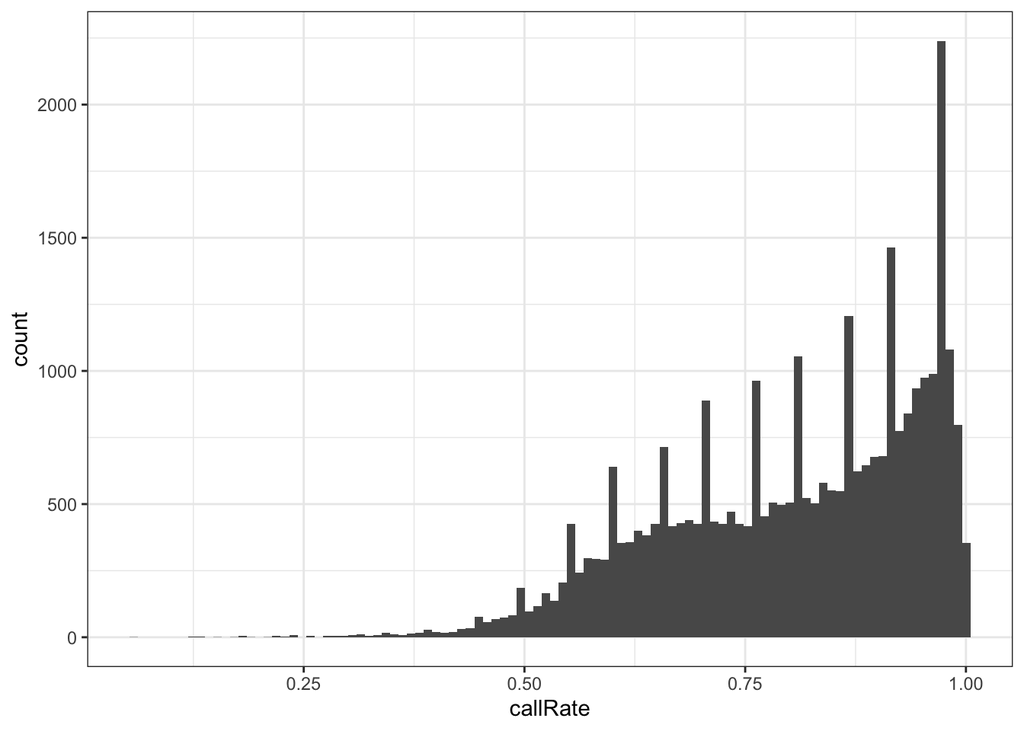

```r
plot3 <- lapply(CallRate2, function(x){
  y <- ggplot(x) + geom_histogram(aes(x=callRate),
                                  bins=100) + theme_bw()

  return(y)
})

plot3[[1]]
```

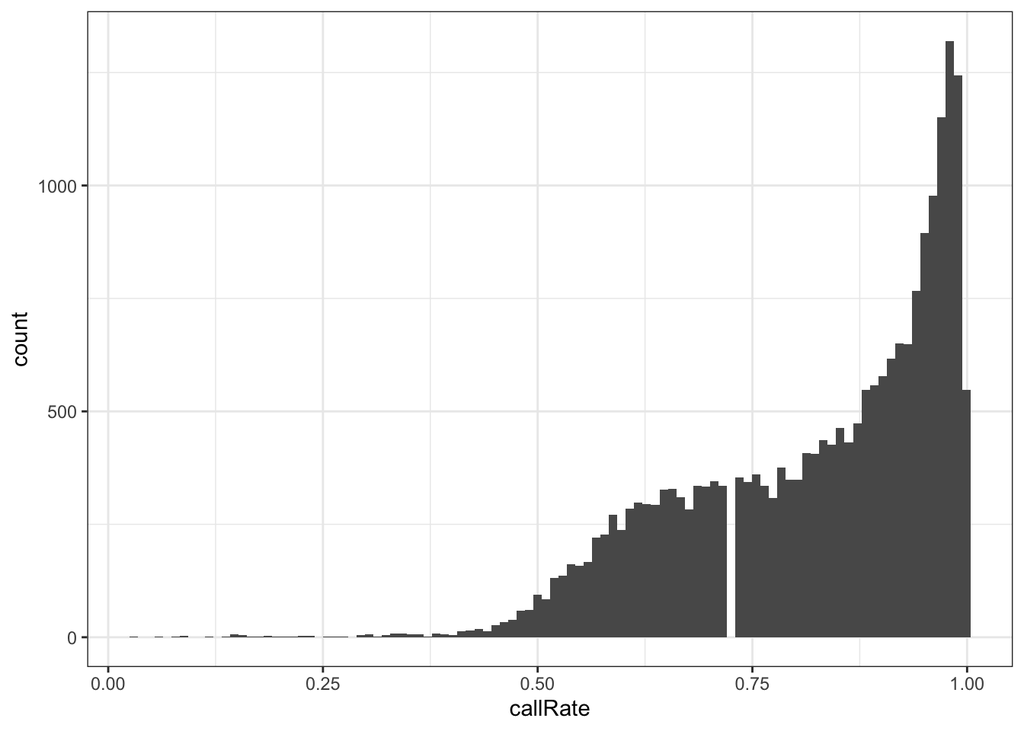

```r
plot3[[2]]
```

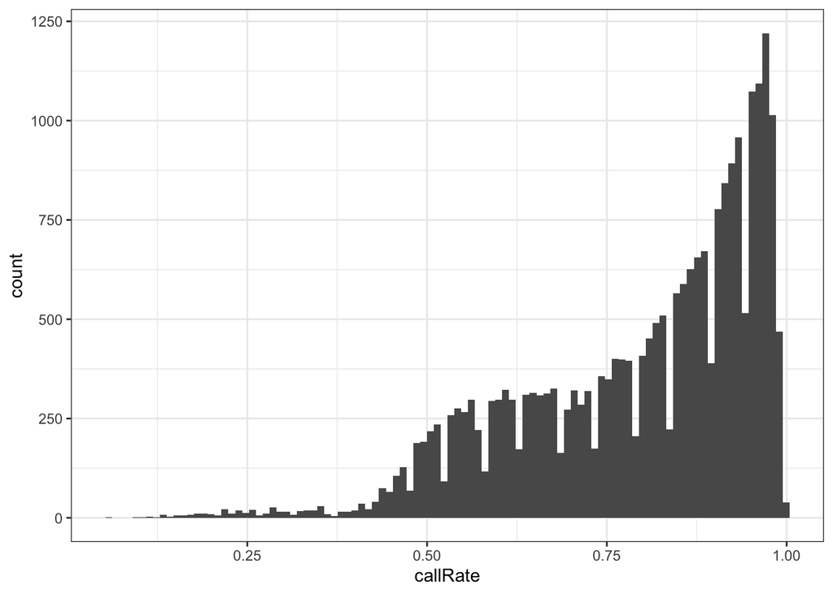

```r
plot3[[3]]
```

I will not filter markers at this stage, as analyses of sex-linkage will include a filter for call rate later on (especially because some of those low call rate could be sex specific in a single species and for biological females, which are present in lower numbers in the dataset).

```r
rm(CallRate2, my.dfs2)
```

What I will do on the other hand is to retain one sample per individual (we currently have multiple technical replicates for ~15% of individuals).

Add column to denote replicate ID

```r
CallRate <- lapply(CallRate, function(x){
  y <- x %>%
    mutate(replica=str_extract(sampleID, "[^_]+$")) %>%
    mutate(replica=case_when(replica == "a" ~ "a",
                           replica == "b" ~ "b",
                           TRUE ~ "norep"))

  return(y)
})
```

Pivot wider to have one observation per sample, retaining only samples where we have at least one replica.

```r
CallRate2 <- lapply(CallRate, function(x){
  y <- x  %>%
    filter(callRate > 0.65) %>%
    filter(replica != "norep") %>%
    mutate(sampleID = str_remove(sampleID, "_a$|_b$")) %>%
    pivot_wider(names_from = replica, values_from = callRate)

  return(y)
})

#also create a vector of all individuals without replicates
#which we want to retain
inds.retain <- lapply(CallRate, function(x){
  y <- x %>%
    filter(callRate > 0.65) %>%
    filter(replica == "norep") %>%
    pull(sampleID)

  return(y)
})
```

Let's assess which replicate has the higher call rate for each sample, and then create a vector containing only those samples with a higher call rate.

```r
inds.retain2 <- lapply(CallRate2, function(x){
  y <- x  %>%
  mutate(best = case_when(is.na(a) == TRUE ~ "b",
                          is.na(b) == TRUE ~ "a",
                          a >= b ~ "a",
                          a < b ~ "b")) %>%
  mutate(sampleID = paste0(sampleID,"_",best))

  z <- y %>% pull(sampleID)

  return(z)
})
```

We will also remove LM_M_JC_Kindie5_M and LM_M_JC_lowerKindie1 as they appeared as outliers in the population structure plots.

```r
inds.retain2$LM <- inds.retain2$LM[!inds.retain2$LM %in%
                                  c("LM_M_JC_lowerKindie1_M_a","LM_M_JC_Kindie5_M_a")]
```

Merge individual IDs for samples with and without replicates that we want to retain

```r
inds.retain <- mapply(function(a,b){
  y <- sort(c(a,b))

  return(y)

}, inds.retain, inds.retain2)
```

And finally filter accordingly

```r
my.dfs <- mapply(function(x,y){
  z <- x[(x$sampleID %in% y),]

  return(z)
}, my.dfs, inds.retain, SIMPLIFY = FALSE)


tempCR <- mapply(function(x,y){
  z <- as_tibble(x[(x$sampleID %in% y),])

  return(z)
}, CallRate, inds.retain, SIMPLIFY = FALSE)
```

Now, let's look at the distribution of call rate once more

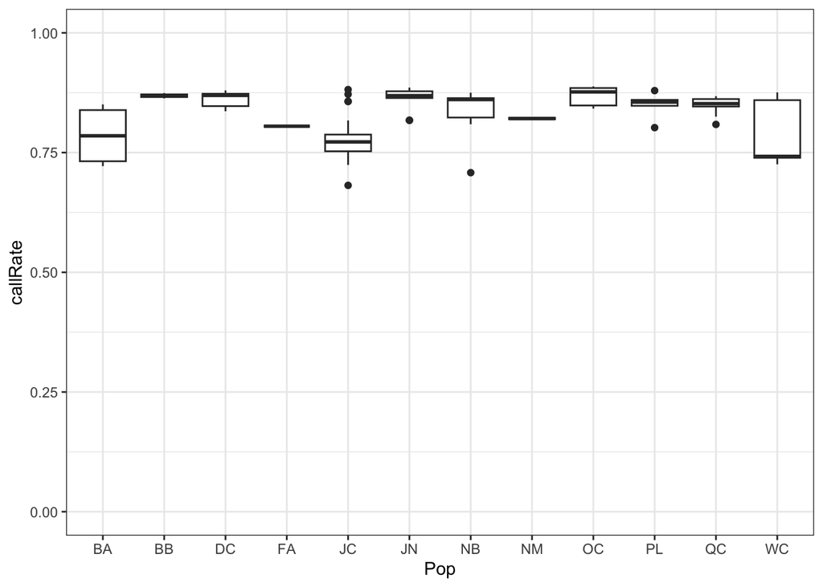

```r
plot4 <- lapply(tempCR, function(x){
  y <- ggplot(x) +
    geom_boxplot(aes(y=callRate,x=Pop)) +
    ylim(0,1) +
    theme_bw()
})

plot4[[1]]
```

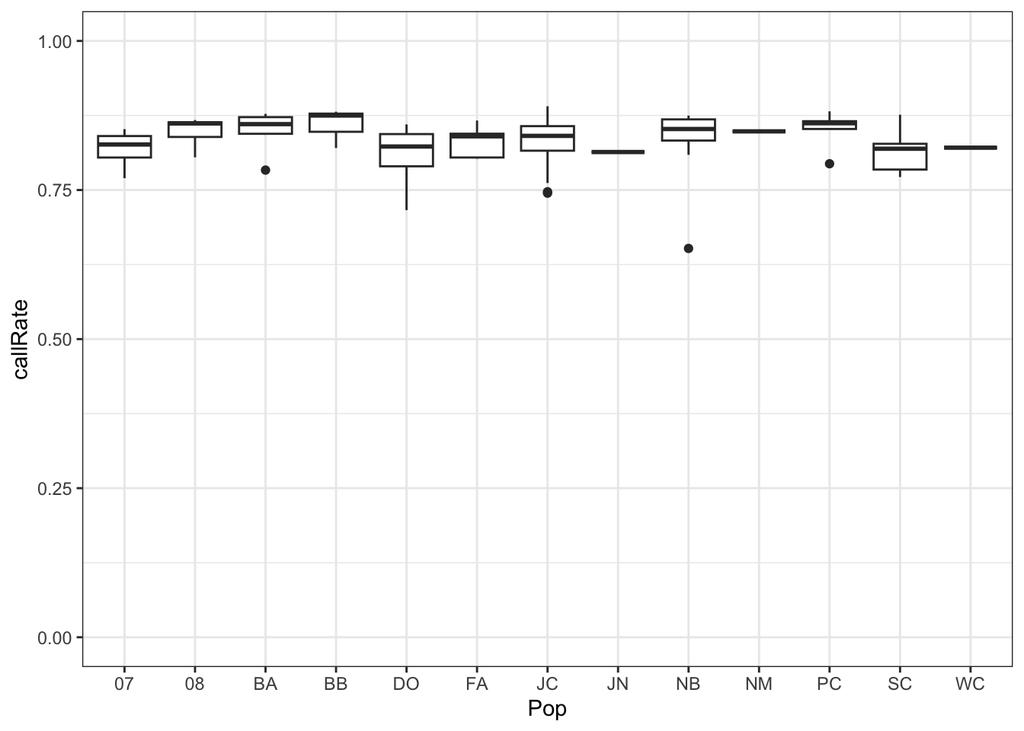

```r
plot4[[2]]
```

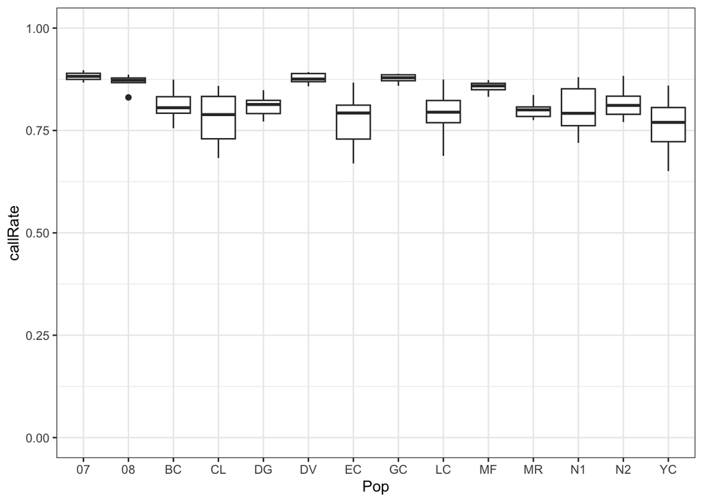

```r
plot4[[3]]
```

## 4. Formatting

First of all, let's save the three dataframes as they are to be used for GWAS analyses later on.

```r
write_delim(my.dfs$LM, file = "../7_GWAS/7_0_input_LM.txt",
            delim = "\t",col_names = TRUE)
write_delim(my.dfs$LS, file = "../7_GWAS/7_0_input_LS.txt",
            delim = "\t",col_names = TRUE)
write_delim(my.dfs$LN, file = "../7_GWAS/7_0_input_LN.txt",
            delim = "\t",col_names = TRUE)
```

Now, to identify sex-linked markers based on heterozygosity, we will need to transpose to have individuals as columns instead of rows.

Remove pop and species information (retained in the sampleID) and transpose

```r
my.dfs <- lapply(my.dfs, function(x){
  y <-  as_tibble(t(x %>% select(-c("Species","Pop"))),
                   rownames = "row_names")

  return(y)
})
```

Turn first row into column names.

```r
my.dfs <- lapply(my.dfs, function(x){
  y <- x %>% row_to_names(row_number = 1)

  return(y)
})
```

Remove all whitespaces produced by t.

```r
my.dfs <- lapply(my.dfs, function(x){
  y <- as_tibble(apply(x, 2, str_remove_all, " "))

  return(y)
})
```

Convert all remaining columns (which include 0,1,2 and -1) to numeric, except for the sampleID column (which actually contains markerIDs now so let's rename it)

```r
my.dfs <- lapply(my.dfs, function(x){
  y <- x %>%
    mutate_at(vars(-("sampleID")),as.numeric) %>%
    rename(markerID = sampleID)
})
```

Then we also remove the "_a" and "_b" at the end of sampleIDs.

```r
my.dfs <- lapply(my.dfs, function(x){
  names(x) <- gsub(pattern = "_a",
                     replacement = "",
                     x = names(x))

  names(x) <- gsub(pattern = "_b",
                     replacement = "",
                     x = names(x))

  return(x)
})
```

Save the resulting files

```r
#saveRDS(my.dfs$LM, file = "../4_filtering/4_3_sexLinked_input_LM.RDS")
#saveRDS(my.dfs$LS, file = "../4_filtering/4_3_sexLinked_input_LS.RDS")
#saveRDS(my.dfs$LN, file = "../4_filtering/4_3_sexLinked_input_LN.RDS")

write_delim(my.dfs$LM, file = "../4_filtering/4_3_filtered_CR65_LM.tsv",
            delim = "\t",col_names = TRUE)
write_delim(my.dfs$LN, file = "../4_filtering/4_3_filtered_CR65_LN.tsv",
            delim = "\t",col_names = TRUE)
write_delim(my.dfs$LS, file = "../4_filtering/4_3_filtered_CR65_LS.tsv",
            delim = "\t",col_names = TRUE)
```

We can now use this file to calculate genotype counts in the males and females of each lineage, and use that information to identify sex-linked markers.

## 5. Concluding remarks

By now yo would have noticed how we were pretty lenient with filtering. For instance, we did not conduct any filtering of the markers by heterozygosity, minor allele counts, call rate, etc.

There are two main reasons for this:

1. When looking for sex-linked markers, we expect markers in the heteromorphic sex to be all heterozygous. Thus, removing based on heterozygous excess would filter out possibly sex-linked markers. A similar thing is true for high missingness. If a sex-linked marker is present in one sex only and not sequenced at all in the other, it would have high missingness, and would thus be filtered out by call rate filters.
2. A lot of the "filtering" will be indirectly conducted when searching for sex-linked markers. This is because we will assess what markers match the expected genotype proportions, and by doing so discard any markers with non-biologically meaningfull proportions of missing data and/or heterozygosity.